# Risk Factor Analysis

## Outcome Variable

**Outcome Variable:** sstunted

## Predictor Variables

**Intervention Variable:** fage

**Adjustment Set:**

- arm
- W_mage
- meducyrs
- feducyrs
- W_mhtcm
- W_mwtkg
- W_mbmi
- W_fhtcm
- single
- brthmon
- delta_W_mage
- delta_meducyrs
- delta_feducyrs
- delta_W_mhtcm
- delta_W_mwtkg
- delta_W_mbmi
- delta_W_fhtcm
- delta_single
- delta_brthmon

## Stratifying Variables

The analysis was stratified on these variable(s):

- agecat
- studyid
- country

## Data Summary

| agecat | studyid | country | fage | sstunted | n_cell | n |
| --- | --- | --- | --- | --- | --- | --- |
| Birth | ki0047075b-MAL-ED | BANGLADESH | >=38 | 0 | 62 | 133 |
| Birth | ki0047075b-MAL-ED | BANGLADESH | >=38 | 1 | 1 | 133 |
| Birth | ki0047075b-MAL-ED | BANGLADESH | <32 | 0 | 24 | 133 |
| Birth | ki0047075b-MAL-ED | BANGLADESH | <32 | 1 | 1 | 133 |
| Birth | ki0047075b-MAL-ED | BANGLADESH | [32-38) | 0 | 44 | 133 |
| Birth | ki0047075b-MAL-ED | BANGLADESH | [32-38) | 1 | 1 | 133 |
| Birth | ki0047075b-MAL-ED | BRAZIL | >=38 | 0 | 5 | 18 |
| Birth | ki0047075b-MAL-ED | BRAZIL | >=38 | 1 | 1 | 18 |
| Birth | ki0047075b-MAL-ED | BRAZIL | <32 | 0 | 1 | 18 |
| Birth | ki0047075b-MAL-ED | BRAZIL | <32 | 1 | 0 | 18 |
| Birth | ki0047075b-MAL-ED | BRAZIL | [32-38) | 0 | 10 | 18 |
| Birth | ki0047075b-MAL-ED | BRAZIL | [32-38) | 1 | 1 | 18 |
| Birth | ki0047075b-MAL-ED | INDIA | >=38 | 0 | 7 | 27 |
| Birth | ki0047075b-MAL-ED | INDIA | >=38 | 1 | 0 | 27 |
| Birth | ki0047075b-MAL-ED | INDIA | <32 | 0 | 8 | 27 |
| Birth | ki0047075b-MAL-ED | INDIA | <32 | 1 | 1 | 27 |
| Birth | ki0047075b-MAL-ED | INDIA | [32-38) | 0 | 10 | 27 |
| Birth | ki0047075b-MAL-ED | INDIA | [32-38) | 1 | 1 | 27 |
| Birth | ki0047075b-MAL-ED | NEPAL | >=38 | 0 | 2 | 9 |
| Birth | ki0047075b-MAL-ED | NEPAL | >=38 | 1 | 0 | 9 |
| Birth | ki0047075b-MAL-ED | NEPAL | <32 | 0 | 2 | 9 |
| Birth | ki0047075b-MAL-ED | NEPAL | <32 | 1 | 0 | 9 |
| Birth | ki0047075b-MAL-ED | NEPAL | [32-38) | 0 | 5 | 9 |
| Birth | ki0047075b-MAL-ED | NEPAL | [32-38) | 1 | 0 | 9 |
| Birth | ki0047075b-MAL-ED | PERU | >=38 | 0 | 23 | 69 |
| Birth | ki0047075b-MAL-ED | PERU | >=38 | 1 | 0 | 69 |
| Birth | ki0047075b-MAL-ED | PERU | <32 | 0 | 22 | 69 |
| Birth | ki0047075b-MAL-ED | PERU | <32 | 1 | 0 | 69 |
| Birth | ki0047075b-MAL-ED | PERU | [32-38) | 0 | 24 | 69 |
| Birth | ki0047075b-MAL-ED | PERU | [32-38) | 1 | 0 | 69 |

[output cut: 180 more lines]

The following strata were considered:

- agecat: 24 months, studyid: ki0047075b-MAL-ED, country: BANGLADESH
- agecat: 24 months, studyid: ki0047075b-MAL-ED, country: BRAZIL
- agecat: 24 months, studyid: ki0047075b-MAL-ED, country: INDIA
- agecat: 24 months, studyid: ki0047075b-MAL-ED, country: NEPAL
- agecat: 24 months, studyid: ki0047075b-MAL-ED, country: PERU
- agecat: 24 months, studyid: ki0047075b-MAL-ED, country: SOUTH AFRICA
- agecat: 24 months, studyid: ki0047075b-MAL-ED, country: TANZANIA, UNITED REPUBLIC OF
- agecat: 24 months, studyid: ki1119695-PROBIT, country: BELARUS
- agecat: 24 months, studyid: ki1135781-COHORTS, country: GUATEMALA
- agecat: 24 months, studyid: ki1135781-COHORTS, country: PHILIPPINES
- agecat: 24 months, studyid: ki1148112-LCNI-5, country: MALAWI
- agecat: 6 months, studyid: ki0047075b-MAL-ED, country: BANGLADESH
- agecat: 6 months, studyid: ki0047075b-MAL-ED, country: BRAZIL
- agecat: 6 months, studyid: ki0047075b-MAL-ED, country: INDIA
- agecat: 6 months, studyid: ki0047075b-MAL-ED, country: NEPAL
- agecat: 6 months, studyid: ki0047075b-MAL-ED, country: PERU
- agecat: 6 months, studyid: ki0047075b-MAL-ED, country: SOUTH AFRICA
- agecat: 6 months, studyid: ki0047075b-MAL-ED, country: TANZANIA, UNITED REPUBLIC OF
- agecat: 6 months, studyid: ki1000304b-SAS-CompFeed, country: INDIA
- agecat: 6 months, studyid: ki1000304b-SAS-FoodSuppl, country: INDIA
- agecat: 6 months, studyid: ki1119695-PROBIT, country: BELARUS
- agecat: 6 months, studyid: ki1135781-COHORTS, country: GUATEMALA
- agecat: 6 months, studyid: ki1135781-COHORTS, country: PHILIPPINES
- agecat: 6 months, studyid: ki1148112-LCNI-5, country: MALAWI
- agecat: Birth, studyid: ki0047075b-MAL-ED, country: BANGLADESH
- agecat: Birth, studyid: ki0047075b-MAL-ED, country: BRAZIL
- agecat: Birth, studyid: ki0047075b-MAL-ED, country: INDIA
- agecat: Birth, studyid: ki0047075b-MAL-ED, country: NEPAL
- agecat: Birth, studyid: ki0047075b-MAL-ED, country: PERU
- agecat: Birth, studyid: ki0047075b-MAL-ED, country: SOUTH AFRICA
- agecat: Birth, studyid: ki0047075b-MAL-ED, country: TANZANIA, UNITED REPUBLIC OF
- agecat: Birth, studyid: ki1000304b-SAS-CompFeed, country: INDIA
- agecat: Birth, studyid: ki1119695-PROBIT, country: BELARUS
- agecat: Birth, studyid: ki1135781-COHORTS, country: GUATEMALA
- agecat: Birth, studyid: ki1135781-COHORTS, country: PHILIPPINES

### Dropped Strata

Some strata were dropped due to rare outcomes:

- agecat: Birth, studyid: ki0047075b-MAL-ED, country: BANGLADESH
- agecat: Birth, studyid: ki0047075b-MAL-ED, country: BRAZIL
- agecat: Birth, studyid: ki0047075b-MAL-ED, country: INDIA
- agecat: Birth, studyid: ki0047075b-MAL-ED, country: NEPAL
- agecat: Birth, studyid: ki0047075b-MAL-ED, country: PERU
- agecat: Birth, studyid: ki0047075b-MAL-ED, country: SOUTH AFRICA
- agecat: Birth, studyid: ki0047075b-MAL-ED, country: TANZANIA, UNITED REPUBLIC OF
- agecat: Birth, studyid: ki1000304b-SAS-CompFeed, country: INDIA
- agecat: Birth, studyid: ki1119695-PROBIT, country: BELARUS
- agecat: Birth, studyid: ki1135781-COHORTS, country: GUATEMALA
- agecat: 6 months, studyid: ki0047075b-MAL-ED, country: BANGLADESH
- agecat: 6 months, studyid: ki0047075b-MAL-ED, country: BRAZIL
- agecat: 6 months, studyid: ki0047075b-MAL-ED, country: INDIA
- agecat: 6 months, studyid: ki0047075b-MAL-ED, country: NEPAL
- agecat: 6 months, studyid: ki0047075b-MAL-ED, country: PERU
- agecat: 6 months, studyid: ki0047075b-MAL-ED, country: SOUTH AFRICA
- agecat: 6 months, studyid: ki0047075b-MAL-ED, country: TANZANIA, UNITED REPUBLIC OF
- agecat: 6 months, studyid: ki1148112-LCNI-5, country: MALAWI
- agecat: 24 months, studyid: ki0047075b-MAL-ED, country: BRAZIL
- agecat: 24 months, studyid: ki0047075b-MAL-ED, country: NEPAL
- agecat: 24 months, studyid: ki0047075b-MAL-ED, country: PERU
- agecat: 24 months, studyid: ki0047075b-MAL-ED, country: SOUTH AFRICA
- agecat: 24 months, studyid: ki1119695-PROBIT, country: BELARUS
- agecat: 24 months, studyid: ki1148112-LCNI-5, country: MALAWI

## Methods Detail

We’re interested in the causal parameters $E[Y_a]$ for all values of $a \in \mathcal{A}$. These parameters represent the mean outcome if, possibly contrary to fact, we intervened to set all units to have $A=a$. Under the randomization and positivity assumptions, these are identified by the statistical parameters $\psi_a=E_W[E_{Y|A,W}(Y|A=a,W)]$. In addition, we’re interested in the mean of $Y$, $E[Y]$ under no intervention (the observed mean). We will estimate these parameters by using SuperLearner to fit the relevant likelihood factors – $E_{Y|A,W}(Y|A=a,W)$ and $p(A=a|W)$, and then updating our likelihood fit using a joint TMLE.

For unadjusted analyses ($W=\{\}$), initial likelihoods were estimated using Lrnr_glm to estimate the simple $E(Y|A)$ and Lrnr_mean to estimate $p(A)$. For adjusted analyses, a small library containing Lrnr_glmnet, Lrnr_xgboost, and Lrnr_mean was used.

Having estimated these parameters, we will then use the delta method to estimate relative risks and attributable risks relative to a prespecified baseline level of $A$.

# Results Detail

## Results Plots

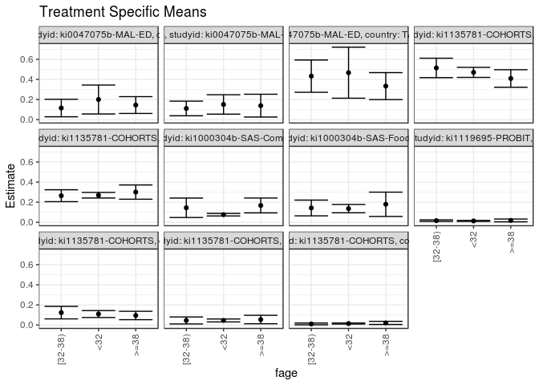

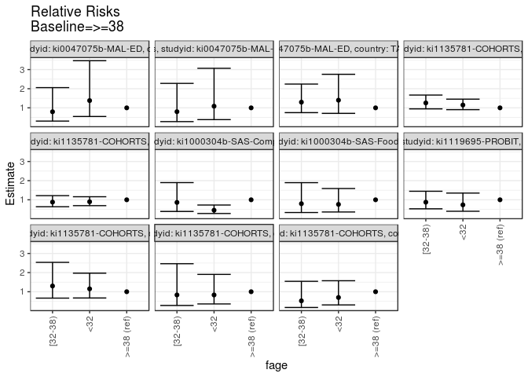

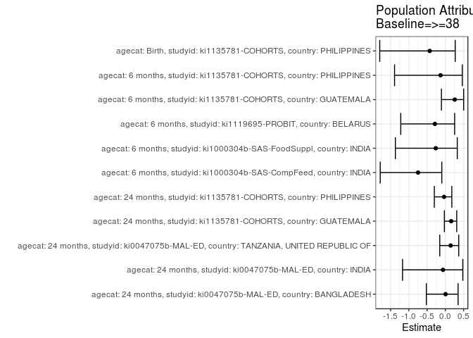

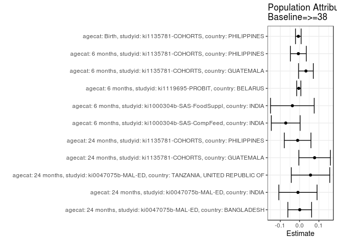

## Results Table

### Parameter: TSM

| agecat | studyid | country | intervention_level | baseline_level | estimate | ci_lower | ci_upper |
| --- | --- | --- | --- | --- | --- | --- | --- |
| Birth | ki1135781-COHORTS | PHILIPPINES | >=38 | NA | 0.0213415 | 0.0056987 | 0.0369842 |
| Birth | ki1135781-COHORTS | PHILIPPINES | <32 | NA | 0.0149110 | 0.0097004 | 0.0201216 |
| Birth | ki1135781-COHORTS | PHILIPPINES | [32-38) | NA | 0.0111732 | 0.0022815 | 0.0200649 |
| 6 months | ki1000304b-SAS-CompFeed | INDIA | >=38 | NA | 0.1678184 | 0.0940350 | 0.2416019 |
| 6 months | ki1000304b-SAS-CompFeed | INDIA | <32 | NA | 0.0761986 | 0.0636062 | 0.0887909 |
| 6 months | ki1000304b-SAS-CompFeed | INDIA | [32-38) | NA | 0.1446514 | 0.0479789 | 0.2413240 |
| 6 months | ki1000304b-SAS-FoodSuppl | INDIA | >=38 | NA | 0.1794872 | 0.0588872 | 0.3000872 |
| 6 months | ki1000304b-SAS-FoodSuppl | INDIA | <32 | NA | 0.1363636 | 0.0949128 | 0.1778145 |
| 6 months | ki1000304b-SAS-FoodSuppl | INDIA | [32-38) | NA | 0.1428571 | 0.0645949 | 0.2211194 |
| 6 months | ki1119695-PROBIT | BELARUS | >=38 | NA | 0.0189802 | 0.0053507 | 0.0326096 |
| 6 months | ki1119695-PROBIT | BELARUS | <32 | NA | 0.0139524 | 0.0088715 | 0.0190332 |
| 6 months | ki1119695-PROBIT | BELARUS | [32-38) | NA | 0.0165930 | 0.0085882 | 0.0245978 |
| 6 months | ki1135781-COHORTS | GUATEMALA | >=38 | NA | 0.0951356 | 0.0533592 | 0.1369120 |
| 6 months | ki1135781-COHORTS | GUATEMALA | <32 | NA | 0.1094437 | 0.0751621 | 0.1437253 |
| 6 months | ki1135781-COHORTS | GUATEMALA | [32-38) | NA | 0.1236066 | 0.0612060 | 0.1860073 |
| 6 months | ki1135781-COHORTS | PHILIPPINES | >=38 | NA | 0.0547825 | 0.0128053 | 0.0967597 |
| 6 months | ki1135781-COHORTS | PHILIPPINES | <32 | NA | 0.0455295 | 0.0310164 | 0.0600425 |
| 6 months | ki1135781-COHORTS | PHILIPPINES | [32-38) | NA | 0.0455886 | 0.0106149 | 0.0805623 |
| 24 months | ki0047075b-MAL-ED | BANGLADESH | >=38 | NA | 0.1449275 | 0.0615895 | 0.2282656 |
| 24 months | ki0047075b-MAL-ED | BANGLADESH | <32 | NA | 0.2000000 | 0.0563881 | 0.3436119 |
| 24 months | ki0047075b-MAL-ED | BANGLADESH | [32-38) | NA | 0.1153846 | 0.0282601 | 0.2025091 |
| 24 months | ki0047075b-MAL-ED | INDIA | >=38 | NA | 0.1388889 | 0.0255672 | 0.2522106 |
| 24 months | ki0047075b-MAL-ED | INDIA | <32 | NA | 0.1509434 | 0.0542630 | 0.2476238 |
| 24 months | ki0047075b-MAL-ED | INDIA | [32-38) | NA | 0.1111111 | 0.0382934 | 0.1839289 |
| 24 months | ki0047075b-MAL-ED | TANZANIA, UNITED REPUBLIC OF | >=38 | NA | 0.3333333 | 0.1993028 | 0.4673638 |
| 24 months | ki0047075b-MAL-ED | TANZANIA, UNITED REPUBLIC OF | <32 | NA | 0.4666667 | 0.2129274 | 0.7204059 |
| 24 months | ki0047075b-MAL-ED | TANZANIA, UNITED REPUBLIC OF | [32-38) | NA | 0.4324324 | 0.2719980 | 0.5928669 |
| 24 months | ki1135781-COHORTS | GUATEMALA | >=38 | NA | 0.4090182 | 0.3217993 | 0.4962371 |
| 24 months | ki1135781-COHORTS | GUATEMALA | <32 | NA | 0.4697648 | 0.4199635 | 0.5195660 |
| 24 months | ki1135781-COHORTS | GUATEMALA | [32-38) | NA | 0.5140909 | 0.4174198 | 0.6107621 |
| 24 months | ki1135781-COHORTS | PHILIPPINES | >=38 | NA | 0.3007241 | 0.2298920 | 0.3715562 |
| 24 months | ki1135781-COHORTS | PHILIPPINES | <32 | NA | 0.2696193 | 0.2418765 | 0.2973621 |
| 24 months | ki1135781-COHORTS | PHILIPPINES | [32-38) | NA | 0.2645416 | 0.2054072 | 0.3236760 |

### Parameter: E(Y)

| agecat | studyid | country | intervention_level | baseline_level | estimate | ci_lower | ci_upper |
| --- | --- | --- | --- | --- | --- | --- | --- |
| Birth | ki1135781-COHORTS | PHILIPPINES | NA | NA | 0.0149457 | 0.0105620 | 0.0193293 |
| 6 months | ki1000304b-SAS-CompFeed | INDIA | NA | NA | 0.0960240 | 0.0777684 | 0.1142796 |
| 6 months | ki1000304b-SAS-FoodSuppl | INDIA | NA | NA | 0.1421053 | 0.1069532 | 0.1772573 |
| 6 months | ki1119695-PROBIT | BELARUS | NA | NA | 0.0147533 | 0.0094871 | 0.0200196 |
| 6 months | ki1135781-COHORTS | GUATEMALA | NA | NA | 0.1280947 | 0.1065929 | 0.1495965 |
| 6 months | ki1135781-COHORTS | PHILIPPINES | NA | NA | 0.0483994 | 0.0401865 | 0.0566123 |
| 24 months | ki0047075b-MAL-ED | BANGLADESH | NA | NA | 0.1456954 | 0.0892366 | 0.2021542 |
| 24 months | ki0047075b-MAL-ED | INDIA | NA | NA | 0.1304348 | 0.0782510 | 0.1826186 |
| 24 months | ki0047075b-MAL-ED | TANZANIA, UNITED REPUBLIC OF | NA | NA | 0.3900000 | 0.2939212 | 0.4860788 |
| 24 months | ki1135781-COHORTS | GUATEMALA | NA | NA | 0.4867777 | 0.4561040 | 0.5174514 |
| 24 months | ki1135781-COHORTS | PHILIPPINES | NA | NA | 0.2905947 | 0.2723152 | 0.3088742 |

### Parameter: RR

| agecat | studyid | country | intervention_level | baseline_level | estimate | ci_lower | ci_upper |
| --- | --- | --- | --- | --- | --- | --- | --- |
| Birth | ki1135781-COHORTS | PHILIPPINES | >=38 | >=38 | 1.0000000 | 1.0000000 | 1.000000 |
| Birth | ki1135781-COHORTS | PHILIPPINES | <32 | >=38 | 0.6986876 | 0.3101923 | 1.573747 |
| Birth | ki1135781-COHORTS | PHILIPPINES | [32-38) | >=38 | 0.5235435 | 0.1774516 | 1.544634 |
| 6 months | ki1000304b-SAS-CompFeed | INDIA | >=38 | >=38 | 1.0000000 | 1.0000000 | 1.000000 |
| 6 months | ki1000304b-SAS-CompFeed | INDIA | <32 | >=38 | 0.4540535 | 0.2834836 | 0.727254 |
| 6 months | ki1000304b-SAS-CompFeed | INDIA | [32-38) | >=38 | 0.8619521 | 0.3915506 | 1.897485 |
| 6 months | ki1000304b-SAS-FoodSuppl | INDIA | >=38 | >=38 | 1.0000000 | 1.0000000 | 1.000000 |
| 6 months | ki1000304b-SAS-FoodSuppl | INDIA | <32 | >=38 | 0.7597403 | 0.3633993 | 1.588350 |
| 6 months | ki1000304b-SAS-FoodSuppl | INDIA | [32-38) | >=38 | 0.7959184 | 0.3344716 | 1.893991 |
| 6 months | ki1119695-PROBIT | BELARUS | >=38 | >=38 | 1.0000000 | 1.0000000 | 1.000000 |
| 6 months | ki1119695-PROBIT | BELARUS | <32 | >=38 | 0.7351009 | 0.4001785 | 1.350331 |
| 6 months | ki1119695-PROBIT | BELARUS | [32-38) | >=38 | 0.8742261 | 0.5283744 | 1.446458 |
| 6 months | ki1135781-COHORTS | GUATEMALA | >=38 | >=38 | 1.0000000 | 1.0000000 | 1.000000 |
| 6 months | ki1135781-COHORTS | GUATEMALA | <32 | >=38 | 1.1503970 | 0.6720511 | 1.969215 |
| 6 months | ki1135781-COHORTS | GUATEMALA | [32-38) | >=38 | 1.2992681 | 0.6662746 | 2.533636 |
| 6 months | ki1135781-COHORTS | PHILIPPINES | >=38 | >=38 | 1.0000000 | 1.0000000 | 1.000000 |
| 6 months | ki1135781-COHORTS | PHILIPPINES | <32 | >=38 | 0.8310950 | 0.3624563 | 1.905661 |
| 6 months | ki1135781-COHORTS | PHILIPPINES | [32-38) | >=38 | 0.8321745 | 0.2811849 | 2.462843 |
| 24 months | ki0047075b-MAL-ED | BANGLADESH | >=38 | >=38 | 1.0000000 | 1.0000000 | 1.000000 |
| 24 months | ki0047075b-MAL-ED | BANGLADESH | <32 | >=38 | 1.3800000 | 0.5499947 | 3.462579 |
| 24 months | ki0047075b-MAL-ED | BANGLADESH | [32-38) | >=38 | 0.7961538 | 0.3081799 | 2.056788 |
| 24 months | ki0047075b-MAL-ED | INDIA | >=38 | >=38 | 1.0000000 | 1.0000000 | 1.000000 |
| 24 months | ki0047075b-MAL-ED | INDIA | <32 | >=38 | 1.0867925 | 0.3851745 | 3.066449 |
| 24 months | ki0047075b-MAL-ED | INDIA | [32-38) | >=38 | 0.8000000 | 0.2809245 | 2.278192 |
| 24 months | ki0047075b-MAL-ED | TANZANIA, UNITED REPUBLIC OF | >=38 | >=38 | 1.0000000 | 1.0000000 | 1.000000 |
| 24 months | ki0047075b-MAL-ED | TANZANIA, UNITED REPUBLIC OF | <32 | >=38 | 1.4000000 | 0.7119272 | 2.753090 |
| 24 months | ki0047075b-MAL-ED | TANZANIA, UNITED REPUBLIC OF | [32-38) | >=38 | 1.2972973 | 0.7506467 | 2.242040 |
| 24 months | ki1135781-COHORTS | GUATEMALA | >=38 | >=38 | 1.0000000 | 1.0000000 | 1.000000 |
| 24 months | ki1135781-COHORTS | GUATEMALA | <32 | >=38 | 1.1485179 | 0.9067594 | 1.454734 |
| 24 months | ki1135781-COHORTS | GUATEMALA | [32-38) | >=38 | 1.2568901 | 0.9471745 | 1.667879 |
| 24 months | ki1135781-COHORTS | PHILIPPINES | >=38 | >=38 | 1.0000000 | 1.0000000 | 1.000000 |
| 24 months | ki1135781-COHORTS | PHILIPPINES | <32 | >=38 | 0.8965671 | 0.6940686 | 1.158146 |
| 24 months | ki1135781-COHORTS | PHILIPPINES | [32-38) | >=38 | 0.8796822 | 0.6364977 | 1.215780 |

### Parameter: PAR

| agecat | studyid | country | intervention_level | baseline_level | estimate | ci_lower | ci_upper |
| --- | --- | --- | --- | --- | --- | --- | --- |
| Birth | ki1135781-COHORTS | PHILIPPINES | >=38 | NA | -0.0063958 | -0.0208660 | 0.0080744 |
| 6 months | ki1000304b-SAS-CompFeed | INDIA | >=38 | NA | -0.0717944 | -0.1464627 | 0.0028738 |
| 6 months | ki1000304b-SAS-FoodSuppl | INDIA | >=38 | NA | -0.0373819 | -0.1504952 | 0.0757313 |
| 6 months | ki1119695-PROBIT | BELARUS | >=38 | NA | -0.0042268 | -0.0150403 | 0.0065866 |
| 6 months | ki1135781-COHORTS | GUATEMALA | >=38 | NA | 0.0329591 | -0.0052089 | 0.0711272 |
| 6 months | ki1135781-COHORTS | PHILIPPINES | >=38 | NA | -0.0063831 | -0.0473798 | 0.0346136 |
| 24 months | ki0047075b-MAL-ED | BANGLADESH | >=38 | NA | 0.0007678 | -0.0607588 | 0.0622945 |
| 24 months | ki0047075b-MAL-ED | INDIA | >=38 | NA | -0.0084541 | -0.1075603 | 0.0906521 |
| 24 months | ki0047075b-MAL-ED | TANZANIA, UNITED REPUBLIC OF | >=38 | NA | 0.0566667 | -0.0430816 | 0.1564149 |
| 24 months | ki1135781-COHORTS | GUATEMALA | >=38 | NA | 0.0777594 | -0.0039291 | 0.1594480 |
| 24 months | ki1135781-COHORTS | PHILIPPINES | >=38 | NA | -0.0101294 | -0.0791587 | 0.0588999 |

### Parameter: PAF

| agecat | studyid | country | intervention_level | baseline_level | estimate | ci_lower | ci_upper |
| --- | --- | --- | --- | --- | --- | --- | --- |
| Birth | ki1135781-COHORTS | PHILIPPINES | >=38 | NA | -0.4279379 | -1.7976835 | 0.2711804 |
| 6 months | ki1000304b-SAS-CompFeed | INDIA | >=38 | NA | -0.7476716 | -1.7843862 | -0.0969585 |
| 6 months | ki1000304b-SAS-FoodSuppl | INDIA | >=38 | NA | -0.2630579 | -1.3691050 | 0.3266169 |
| 6 months | ki1119695-PROBIT | BELARUS | >=38 | NA | -0.2865009 | -1.2211360 | 0.2548478 |
| 6 months | ki1135781-COHORTS | GUATEMALA | >=38 | NA | 0.2573028 | -0.1071393 | 0.5017798 |
| 6 months | ki1135781-COHORTS | PHILIPPINES | >=38 | NA | -0.1318839 | -1.3919066 | 0.4643765 |
| 24 months | ki0047075b-MAL-ED | BANGLADESH | >=38 | NA | 0.0052701 | -0.5208155 | 0.3493704 |
| 24 months | ki0047075b-MAL-ED | INDIA | >=38 | NA | -0.0648148 | -1.1729436 | 0.4782052 |
| 24 months | ki0047075b-MAL-ED | TANZANIA, UNITED REPUBLIC OF | >=38 | NA | 0.1452991 | -0.1531681 | 0.3665160 |
| 24 months | ki1135781-COHORTS | GUATEMALA | >=38 | NA | 0.1597432 | -0.0263549 | 0.3120982 |
| 24 months | ki1135781-COHORTS | PHILIPPINES | >=38 | NA | -0.0348575 | -0.3019799 | 0.1774604 |